# Stroke Prediction

Cynthia Matuli

2026-05-02

**PREDICTIVE MODELLING FOR STROKE**

Stroke is a leading cause of disability and death worldwide with LMICs accounting for three-quarters of all stroke cases. These are, however, deaths and complications that are preventable with early detection. Data Science methods such as Machine Learning predictive modelling and classification techniques including logistic regression, Gradient Boosting Trees, and Random Forest have stronger generalization and feature expression capabilities to learn and map complex nonlinear relationship between variables; and therefore, better at predicting high risk stroke patients.

- Primary objective is to develop a predictive model for stroke.
- Secondary objectives;
  - Compare the predictive performance of:
    - Logistic regression
    - Decision tree
    - Random forest
    - XGBoost
  - Select the best-performing model.
  - Report the important predictors from that model.

```r
library(writexl); library(openxlsx); library(tinytex); library(formatR)
library(readxl); library(xgboost); library(caret); library(Matrix)
library(tidyverse); library(forcats); library(stringr); library(nnet)
library(readxl);library(dplyr);library(ggplot2);library(pROC);library(ggthemes);
library(gtsummary);library(flextable);library(broom.helpers); library(xfun);
library(corrplot); library(rsample); library(recipes); library(parsnip); library(tune)
library(dials); library(yardstick); library(naniar); library(baguette)
```

```r
stroke_prediction <- read_excel("ANALYSIS DATASETS/stroke_prediction.xlsx")
View(stroke_prediction)


#Structure of the dataset
str(stroke_prediction)
```

```
## tibble [5,110 × 12] (S3: tbl_df/tbl/data.frame)
##  $ id               : num [1:5110] 9046 51676 31112 60182 1665 ...
##  $ gender           : chr [1:5110] "Male" "Female" "Male" "Female" ...
##  $ age              : num [1:5110] 67 61 80 49 79 81 74 69 59 78 ...
##  $ hypertension     : num [1:5110] 0 0 0 0 1 0 1 0 0 0 ...
##  $ heart_disease    : num [1:5110] 1 0 1 0 0 0 1 0 0 0 ...
##  $ ever_married     : chr [1:5110] "Yes" "Yes" "Yes" "Yes" ...
##  $ work_type        : chr [1:5110] "Private" "Self-employed" "Private" "Private" ...
##  $ Residence_type   : chr [1:5110] "Urban" "Rural" "Rural" "Urban" ...
##  $ avg_glucose_level: num [1:5110] 229 202 106 171 174 ...
##  $ bmi              : chr [1:5110] "36.6" "N/A" "32.5" "34.4" ...
##  $ smoking_status   : chr [1:5110] "formerly smoked" "never smoked" "never smoked" "smokes" ...
##  $ stroke           : num [1:5110] 1 1 1 1 1 1 1 1 1 1 ...
```

**Understanding the dataset:

- The dataset has 5110 entries and 12 variables. 3 numerical variables and 9 categorical variables.
- id: unique identifier
- gender: “Male”, “Female” or “Other”
- age: age of the patient
- hypertension: 0 if the patient does not have hypertension, 1 if the patient has hypertension
- heart_disease: 0 if the patient does not have any heart diseases, 1 if the patient has a heart disease.
- ever_married: “No” or “Yes”.
- work_type: “children”, “Govt_jov”, “Never_worked”, “Private” or “Self-employed”.
- Residence_type: “Rural” or “Urban”.
- avg_glucose_level: average glucose level in blood.
- bmi: body mass index
- smoking_status: “formerly smoked”, “never smoked”, “smokes” or “Unknown”.
- stroke: 1 if the patient had a stroke or 0 if not.

```r
#Overview of the unique entries of the dataset
glimpse(stroke_prediction)
```

```
## Rows: 5,110
## Columns: 12
## $ id                <dbl> 9046, 51676, 31112, 60182, 1665, 56669, 53882, 10434…
## $ gender            <chr> "Male", "Female", "Male", "Female", "Female", "Male"…
## $ age               <dbl> 67, 61, 80, 49, 79, 81, 74, 69, 59, 78, 81, 61, 54, …
## $ hypertension      <dbl> 0, 0, 0, 0, 1, 0, 1, 0, 0, 0, 1, 0, 0, 0, 0, 1, 0, 1…
## $ heart_disease     <dbl> 1, 0, 1, 0, 0, 0, 1, 0, 0, 0, 0, 1, 0, 1, 1, 0, 1, 0…
## $ ever_married      <chr> "Yes", "Yes", "Yes", "Yes", "Yes", "Yes", "Yes", "No…
## $ work_type         <chr> "Private", "Self-employed", "Private", "Private", "S…
## $ Residence_type    <chr> "Urban", "Rural", "Rural", "Urban", "Rural", "Urban"…
## $ avg_glucose_level <dbl> 228.69, 202.21, 105.92, 171.23, 174.12, 186.21, 70.0…
## $ bmi               <chr> "36.6", "N/A", "32.5", "34.4", "24", "29", "27.4", "…
## $ smoking_status    <chr> "formerly smoked", "never smoked", "never smoked", "…
## $ stroke            <dbl> 1, 1, 1, 1, 1, 1, 1, 1, 1, 1, 1, 1, 1, 1, 1, 1, 1, 1…
```

```r
#Summary of the variables
stroke_prediction %>%
summary()
```

```
##        id              gender          age         hypertension
##  Min.   :   67   Length   :5110   Min.   : 0.08   Min.   :0.00000
##  1st Qu.:17741   N.unique :   3   1st Qu.:25.00   1st Qu.:0.00000
##  Median :36932   N.blank  :   0   Median :45.00   Median :0.00000
##  Mean   :36518   Min.nchar:   4   Mean   :43.23   Mean   :0.09746
##  3rd Qu.:54682   Max.nchar:   6   3rd Qu.:61.00   3rd Qu.:0.00000
##  Max.   :72940                    Max.   :82.00   Max.   :1.00000
##  heart_disease        ever_married      work_type      Residence_type
##  Min.   :0.00000   Length   :5110   Length   :5110   Length   :5110
##  1st Qu.:0.00000   N.unique :   2   N.unique :   5   N.unique :   2
##  Median :0.00000   N.blank  :   0   N.blank  :   0   N.blank  :   0
##  Mean   :0.05401   Min.nchar:   2   Min.nchar:   7   Min.nchar:   5
##  3rd Qu.:0.00000   Max.nchar:   3   Max.nchar:  13   Max.nchar:   5
##  Max.   :1.00000
##  avg_glucose_level        bmi         smoking_status     stroke
##  Min.   : 55.12    Length   :5110   Length   :5110   Min.   :0.00000
##  1st Qu.: 77.25    N.unique : 419   N.unique :   4   1st Qu.:0.00000
##  Median : 91.89    N.blank  :   0   N.blank  :   0   Median :0.00000
##  Mean   :106.15    Min.nchar:   2   Min.nchar:   6   Mean   :0.04873
##  3rd Qu.:114.09    Max.nchar:  18   Max.nchar:  15   3rd Qu.:0.00000
##  Max.   :271.74                                      Max.   :1.00000
```

**Analysis of the unique entries:

- bmi is read as a character yet it is a numerical variable.
- hypertension, heart_disease, and stroke - should be converted to factor variables.
- Age has a minimum of 0.08. Very unlikely especially for an individual likely to suffer from stroke.

```r
#Looking for duplicates
stroke_prediction %>%
  count(id) %>%
  arrange(desc(n))
```

```
## # A tibble: 5,110 × 2
##       id     n
##    <dbl> <int>
##  1    67     1
##  2    77     1
##  3    84     1
##  4    91     1
##  5    99     1
##  6   121     1
##  7   129     1
##  8   132     1
##  9   156     1
## 10   163     1
## # ℹ 5,100 more rows
```

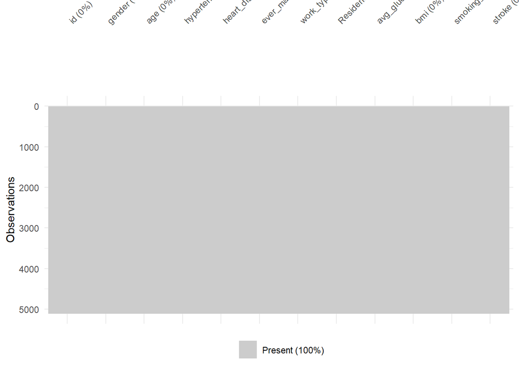

```r
#Missing values and the nature of missingness
stroke_prediction %>%
  naniar::vis_miss()
```

- The dataset has no duplicates.
- There are no missing values. Further exploration of the unique entries through descriptive statistics

**Variable preprocessing**

```r
#Recoding stroke to read names instead of numbers
table(stroke_prediction$stroke)
```

```
##
##    0    1
## 4861  249
```

```r
stroke_prediction <- stroke_prediction %>%
  mutate(stroke_recorded = case_when(
    stroke == 0 ~ "No stroke",
    stroke == 1 ~ "Stroke",
    TRUE ~ NA
  )) %>%
  mutate(stroke_recorded = factor(stroke_recorded,
                                  levels = c("No stroke", "Stroke"))) %>%
  relocate(stroke_recorded, .after = stroke)

table(stroke_prediction$stroke_recorded)
```

```
##
## No stroke    Stroke
##      4861       249
```

```r
#Removing 'Other' in gender since it is only 1 entry
table(stroke_prediction$gender)
```

```
##
## Female   Male  Other
##   2994   2115      1
```

```r
stroke_prediction <- stroke_prediction %>%
  filter(!(gender == "Other")) %>%
  mutate(gender = factor(gender,
                         levels = c("Female", "Male")))

table(stroke_prediction$gender)
```

```
##
## Female   Male
##   2994   2115
```

```r
#Recoding age into groups.
summary(stroke_prediction$age) #Minimum age is 0.08 and max is 82.0
```

```
##    Min. 1st Qu.  Median    Mean 3rd Qu.    Max.
##    0.08   25.00   45.00   43.23   61.00   82.00
```

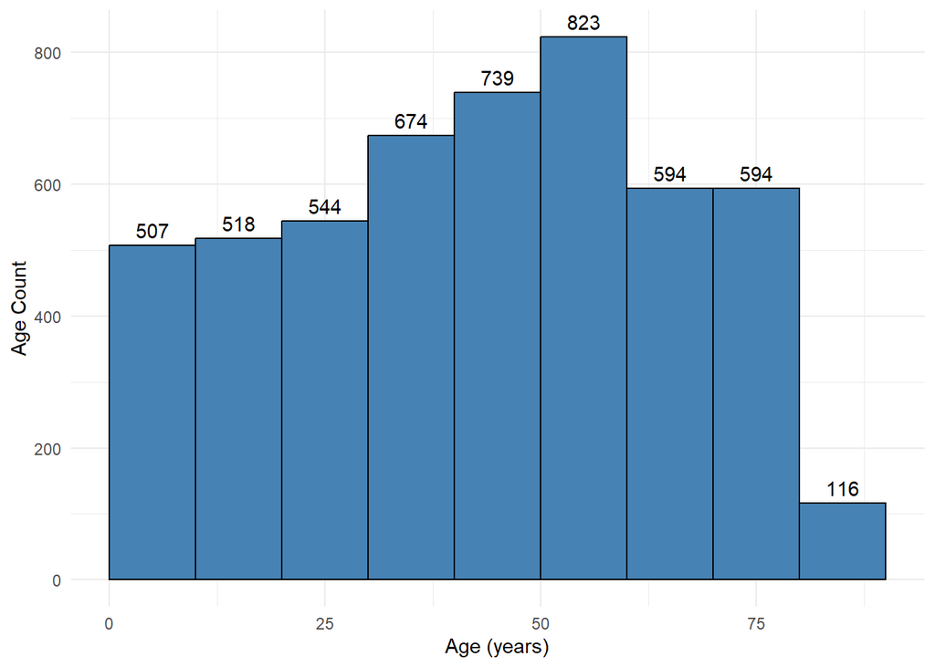

```r
stroke_prediction$age <- as.numeric(stroke_prediction$age)

stroke_prediction <- stroke_prediction %>%
  mutate(age = floor(age)) %>% #Rounding down age to remove decimals
  arrange(age)


#Histogram to explore age
stroke_prediction %>%
  ggplot(aes(x = age)) +
  geom_histogram(binwidth = 10, fill = "steelblue", color = "black",
                 boundary = min(stroke_prediction$age, na.rm = TRUE)) +
  stat_bin(binwidth = 10,
           geom = "text",
           aes(label = after_stat(count)),
           vjust = -0.5,
           boundary = min(stroke_prediction$age,
                          na.rm = TRUE)) +
  labs(x = "Age (years)", y = "Age Count") +
  theme_minimal()
```

There are some children in the dataset and predicting their stroke chances will most likely skew or mislead the model. I will structure the dataset into several parts.

1. Create a dataset for adults 40 years of age and above (>= 40yrs)
2. Create a dataset for individuals >=18years of age (I’ll work with this later)

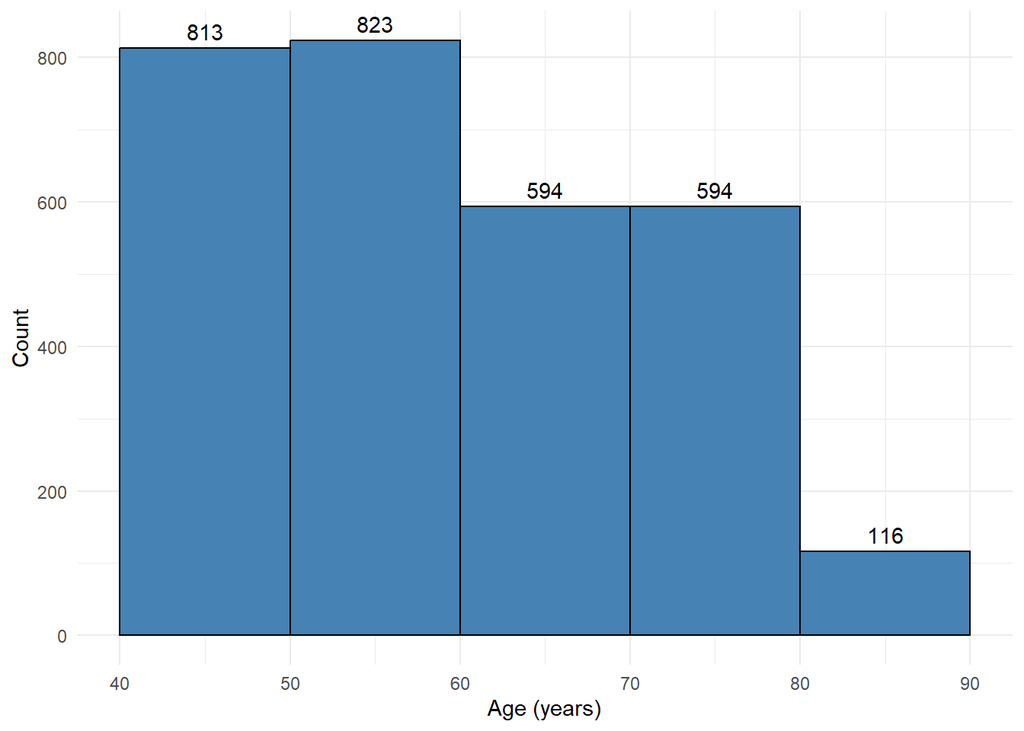

```r
#Eliminating individuals below 40years of age
stroke_prediction <- stroke_prediction %>%
  filter(age >= 40)

stroke_prediction %>%
  ggplot(aes(x = age)) +
  geom_histogram(binwidth = 10, fill = "steelblue", color = "black",
                 boundary = min(stroke_prediction$age, na.rm = TRUE)) +
  stat_bin(binwidth = 10,
           geom = "text",
           aes(label = after_stat(count)),
           vjust = -0.5,
           boundary = min(stroke_prediction$age,
                          na.rm = TRUE)) +
  labs(x = "Age (years)", y = "Count") +
  theme_minimal()
```

```r
#Recoding age into age-groups
stroke_prediction <- stroke_prediction %>%
  mutate(age_group = case_when(
    age < 45 ~ "Young adults (<45)",
    age >= 45 & age < 65 ~ "Middle aged (45-64)",
    age >= 65 ~ "Elderly (>=65)",
    TRUE ~ NA
  )) %>%
  mutate(age_group = factor(age_group,
                            levels = c("Young adults (<45)", "Middle aged (45-64)", "Elderly (>=65)"))) %>%
  relocate(age_group, .after = age)

table(stroke_prediction$stroke_recorded, stroke_prediction$age_group)
```

```
##
##             Young adults (<45) Middle aged (45-64) Elderly (>=65)
##   No stroke                361                1470            868
##   Stroke                     2                  80            159
```

```r
#Exploring work type.
table(stroke_prediction$work_type)
```

```
##
##      Govt_job       Private Self-employed
##           500          1728           712
```

Does not show evidence of data sparsity.

```r
#Converting bmi to numeric
class(stroke_prediction$bmi)
```

```
## [1] "character"
```

```r
stroke_prediction$bmi <- as.numeric(stroke_prediction$bmi)
summary(stroke_prediction$bmi)
```

```
##    Min. 1st Qu.  Median    Mean 3rd Qu.    Max.     NAs
##   11.30   26.30   29.80   30.85   34.40   71.90     145
```

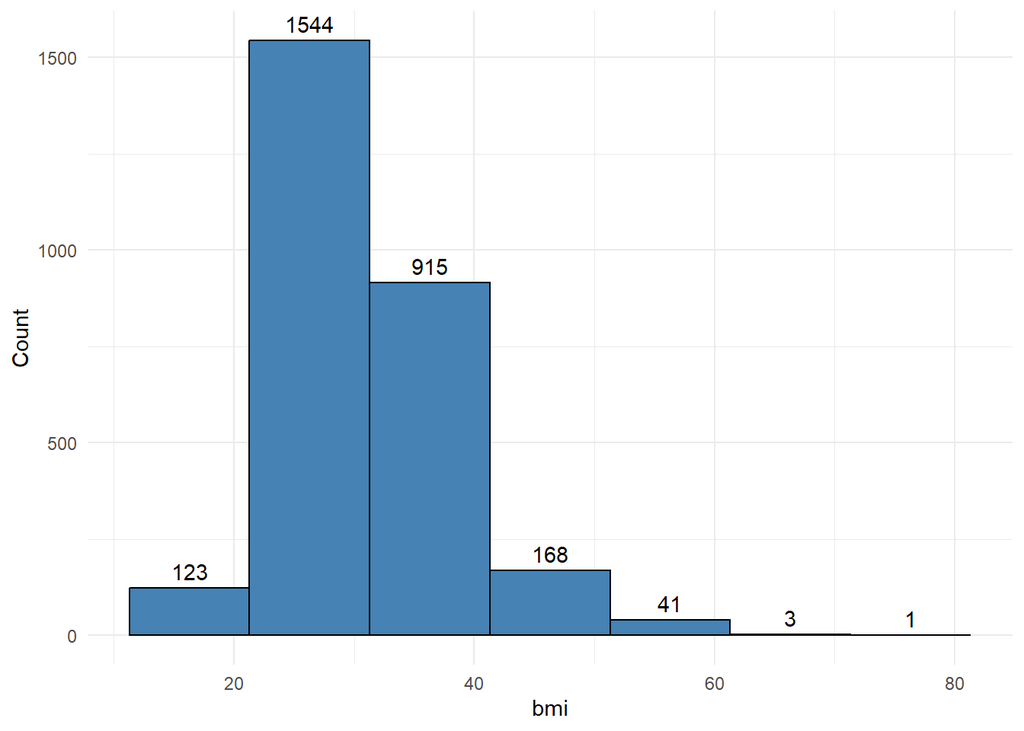

```r
#Visualizing the distribution of bmi
stroke_prediction %>%
  ggplot(aes(x = bmi)) +
  geom_histogram(binwidth = 10, fill = "steelblue", color = "black",
                 boundary = min(stroke_prediction$bmi, na.rm = TRUE)) +
  stat_bin(binwidth = 10,
           geom = "text",
           aes(label = after_stat(count)),
           vjust = -0.5,
           boundary = min(stroke_prediction$bmi,
                          na.rm = TRUE)) +
  labs(x = "bmi", y = "Count") +
  theme_minimal()
```

- Summary of bmi: its shows 145 missing entries. I shall impute when doing feature engineering to prevent data leakage. I shall impute with the median value.
- The histogram shows that bmi is skewed to the right.

```r
#Recoding bmi levels into clinical ranges
stroke_prediction <- stroke_prediction %>%
  mutate(bmi_weight_obesity = case_when(
    bmi < 18.5 ~ "Underweight (<18.5)",
    bmi >= 18.5 & bmi < 25.0 ~ "Normal (18.5-24.9)",
    bmi >= 25.0 & bmi < 30.0 ~ "Overweight (25.0-30.0)",
    bmi >= 30.0 ~ "Obesity (>=30.0)",
    TRUE ~ NA
  )) %>%
  mutate(bmi_weight_obesity = factor(bmi_weight_obesity,
                                     levels = c("Obesity (>=30.0)", "Underweight (<18.5)", "Normal (18.5-24.9)", "Overweight (25.0-30.0)"))) %>%
  relocate(bmi_weight_obesity, .after = bmi)

table(stroke_prediction$bmi_weight_obesity)
```

```
##
##       Obesity (>=30.0)    Underweight (<18.5)     Normal (18.5-24.9)
##                   1368                     25                    465
## Overweight (25.0-30.0)
##                    937
```

```r
table(stroke_prediction$bmi_weight_obesity, stroke_prediction$stroke_recorded)
```

```
##
##                          No stroke Stroke
##   Obesity (>=30.0)            1272     96
##   Underweight (<18.5)           24      1
##   Normal (18.5-24.9)           431     34
##   Overweight (25.0-30.0)       865     72
```

- Reference for the clinical ranges: https://apps.who.int/nutrition/landscape/help.aspx?menu=0&helpid=420

The recoded bmi variable based on the clinical ranges shows a high degree of data sparsity. Individuals recoded as underweight are only 25 and only 1 individual has stroke. This would lead to unstable model estimates. I will collapse this group and combine it with individuals recoded as having normal weight.

```r
#Recoding bmi levels into clinical ranges
stroke_prediction <- stroke_prediction %>%
  mutate(bmi_weight_obesity = case_when(
    bmi < 25.0 ~ "Underweight/Normal (<25.0)",
    bmi >= 25.0 & bmi < 30.0 ~ "Overweight (25.0-30.0)",
    bmi >= 30.0 ~ "Obesity (>=30.0)",
    TRUE ~ NA
  )) %>%
  mutate(bmi_weight_obesity = factor(bmi_weight_obesity,
                                     levels = c("Obesity (>=30.0)", "Underweight/Normal (<25.0)", "Overweight (25.0-30.0)"))) %>%
  relocate(bmi_weight_obesity, .after = bmi)

table(stroke_prediction$bmi_weight_obesity)
```

```
##
##           Obesity (>=30.0) Underweight/Normal (<25.0)
##                       1368                        490
##     Overweight (25.0-30.0)
##                        937
```

```r
table(stroke_prediction$bmi_weight_obesity, stroke_prediction$stroke_recorded)
```

```
##
##                              No stroke Stroke
##   Obesity (>=30.0)                1272     96
##   Underweight/Normal (<25.0)       455     35
##   Overweight (25.0-30.0)           865     72
```

```r
#Visualizing the distribution of average glucose level
summary(stroke_prediction$avg_glucose_level)
```

```
##    Min. 1st Qu.  Median    Mean 3rd Qu.    Max.
##   55.22   78.43   94.67  114.09  126.89  271.74
```

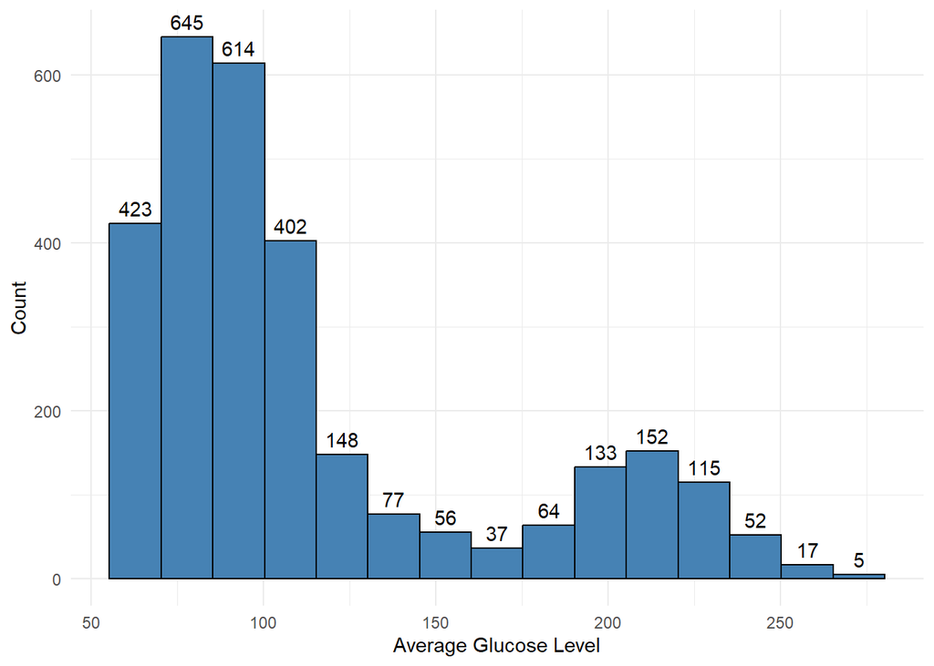

```r
stroke_prediction %>%
  ggplot(aes(x = avg_glucose_level)) +
  geom_histogram(binwidth = 15, fill = "steelblue", color = "black",
                 boundary = min(stroke_prediction$avg_glucose_level, na.rm = TRUE)) +
  stat_bin(binwidth = 15,
           geom = "text",
           aes(label = after_stat(count)),
           vjust = -0.5,
           boundary = min(stroke_prediction$avg_glucose_level,
                          na.rm = TRUE)) +
  labs(x = "Average Glucose Level", y = "Count") +
  theme_minimal()
```

The distribution is bimodal.

```r
#Recoding average glucose levels into clinical ranges
stroke_prediction <- stroke_prediction %>%
  mutate(avg_glucose_level_diabetes = case_when(
    avg_glucose_level < 117 ~ "Normal (<117mg/dL)",
    avg_glucose_level >= 117 & avg_glucose_level < 137 ~ "Prediabetes (117-136mg/dL)",
    avg_glucose_level >= 137 ~ "Diabetes (>=137mg/dL)",
    TRUE ~ NA
  )) %>%
  mutate(avg_glucose_level_diabetes = factor(avg_glucose_level_diabetes,
                                             levels = c("Normal (<117mg/dL)", "Prediabetes (117-136mg/dL)", "Diabetes (>=137mg/dL)"))) %>%
  relocate(avg_glucose_level_diabetes, .after = avg_glucose_level)

table(stroke_prediction$avg_glucose_level_diabetes)
```

```
##
##         Normal (<117mg/dL) Prediabetes (117-136mg/dL)
##                       2114                        151
##      Diabetes (>=137mg/dL)
##                        675
```

- Reference for the clinical ranges: https://my.clevelandclinic.org/health/diagnostics/9731-a1c
- The groups seems okay.

```r
#Recoding smoking status to smokers and non-smokers and unknown (is quite a %)
table(stroke_prediction$smoking_status)
```

```
##
## formerly smoked    never smoked          smokes         Unknown
##             703            1161             514             562
```

```r
#Combining formerly smoked and smokes into 1 group
stroke_prediction <- stroke_prediction %>%
  mutate(smoking_status_recorded = case_when(
    smoking_status == "never smoked" ~ "Non-smokers",
    smoking_status %in% c("formerly smoked", "smokes") ~ "Smokers",
    smoking_status == "Unknown" ~ "Unknown"
  )) %>%
  mutate(smoking_status_recorded = factor(smoking_status_recorded,
                                          levels = c("Non-smokers", "Smokers", "Unknown"))) %>%
  relocate(smoking_status_recorded, .after = smoking_status)

table(stroke_prediction$smoking_status_recorded)
```

```
##
## Non-smokers     Smokers     Unknown
##        1161        1217         562
```

```r
#ever_married into a factor
table(stroke_prediction$ever_married)
```

```
##
##   No  Yes
##  258 2682
```

```r
stroke_prediction <- stroke_prediction %>%
  mutate(ever_married = factor(ever_married))
```

- 91% of the individuals have ever been married.

```r
#heart_disease
table(stroke_prediction$heart_disease)
```

```
##
##    0    1
## 2667  273
```

```r
stroke_prediction <- stroke_prediction %>%
  mutate(heart_disease_recorded = case_when(
    heart_disease == 0 ~ "No",
    heart_disease == 1 ~ "Yes",
    TRUE ~ NA)) %>%
  mutate(heart_disease_recorded = factor(heart_disease_recorded,
                                         levels = c("No", "Yes"))) %>%
  relocate(heart_disease_recorded, .after = heart_disease)

table(stroke_prediction$heart_disease_recorded)
```

```
##
##   No  Yes
## 2667  273
```

- 90% of the individuals do not have heart disease

```r
#hypertension
table(stroke_prediction$hypertension)
```

```
##
##    0    1
## 2479  461
```

```r
stroke_prediction <- stroke_prediction %>%
  mutate(hypertension_recorded = case_when(
    hypertension == 0 ~ "No",
    hypertension == 1 ~ "Yes",
    TRUE ~ NA)) %>%
  mutate(hypertension_recorded = factor(hypertension_recorded,
                                         levels = c("No", "Yes"))) %>%
  relocate(hypertension_recorded, .after = hypertension)

table(stroke_prediction$hypertension_recorded)
```

```
##
##   No  Yes
## 2479  461
```

- 84% of the individuals do not have hypertension.

**Assessing the association between variables and the outcome of interest**

*Hypothesis testing*

1. Chi-square test

```
- Testing whether categorical variables have any association with the outcome variable (stroke)

- Hypothesis;
Null: Predictor variables have no association with the dependent variable.
Alternative: Predictor variables have an association with the dependent variable.

- Significance level; 0.05
```

2. Wilcoxon test

```
- Testing whether there is a difference in the medians of numerical variables.

- Hypothesis;
Null: There is no difference in the median values between groups.
Alternative: There is a difference in the median value between groups.

- Significance level; 0.05
```

```r
#Descriptive statistics
descriptive <- stroke_prediction %>%
  select(gender:age_group, hypertension_recorded, heart_disease_recorded, ever_married:bmi, bmi_weight_obesity, smoking_status_recorded, stroke_recorded) %>%
  tbl_summary(by = stroke_recorded,
              type = list(all_categorical() ~ "categorical"), missing = "ifany") %>%
  add_overall() %>%
  add_p()
descriptive
```

| **Characteristic** | **Overall** N = 2,940<sup>1</sup> | **No stroke** N = 2,699<sup>1</sup> | **Stroke** N = 241<sup>1</sup> | **p-value**<sup>2</sup> |
| --- | --- | --- | --- | --- |
| gender |  |  |  | 0.3 |
| Female | 1,723 (59%) | 1,590 (59%) | 133 (55%) |  |
| Male | 1,217 (41%) | 1,109 (41%) | 108 (45%) |  |
| age | 58 (50, 70) | 57 (49, 68) | 72 (60, 78) | <0.001 |
| age_group |  |  |  | <0.001 |
| Young adults (<45) | 363 (12%) | 361 (13%) | 2 (0.8%) |  |
| Middle aged (45-64) | 1,550 (53%) | 1,470 (54%) | 80 (33%) |  |
| Elderly (>=65) | 1,027 (35%) | 868 (32%) | 159 (66%) |  |
| hypertension_recorded |  |  |  | <0.001 |
| No | 2,479 (84%) | 2,303 (85%) | 176 (73%) |  |
| Yes | 461 (16%) | 396 (15%) | 65 (27%) |  |
| heart_disease_recorded |  |  |  | <0.001 |
| No | 2,667 (91%) | 2,473 (92%) | 194 (80%) |  |
| Yes | 273 (9.3%) | 226 (8.4%) | 47 (20%) |  |
| ever_married |  |  |  | 0.2 |
| No | 258 (8.8%) | 232 (8.6%) | 26 (11%) |  |
| Yes | 2,682 (91%) | 2,467 (91%) | 215 (89%) |  |
| work_type |  |  |  | 0.3 |
| Govt_job | 500 (17%) | 467 (17%) | 33 (14%) |  |
| Private | 1,728 (59%) | 1,583 (59%) | 145 (60%) |  |
| Self-employed | 712 (24%) | 649 (24%) | 63 (26%) |  |
| Residence_type |  |  |  | 0.3 |
| Rural | 1,440 (49%) | 1,330 (49%) | 110 (46%) |  |
| Urban | 1,500 (51%) | 1,369 (51%) | 131 (54%) |  |
| avg_glucose_level | 95 (78, 127) | 94 (78, 123) | 107 (80, 197) | <0.001 |
| avg_glucose_level_diabetes |  |  |  | <0.001 |
| Normal (<117mg/dL) | 2,114 (72%) | 1,976 (73%) | 138 (57%) |  |
| Prediabetes (117-136mg/dL) | 151 (5.1%) | 142 (5.3%) | 9 (3.7%) |  |
| Diabetes (>=137mg/dL) | 675 (23%) | 581 (22%) | 94 (39%) |  |
| bmi | 30 (26, 34) | 30 (26, 34) | 30 (26, 34) | 0.5 |
| Unknown | 145 | 107 | 38 |  |
| bmi_weight_obesity |  |  |  | 0.8 |
| Obesity (>=30.0) | 1,368 (49%) | 1,272 (49%) | 96 (47%) |  |
| Underweight/Normal (<25.0) | 490 (18%) | 455 (18%) | 35 (17%) |  |
| Overweight (25.0-30.0) | 937 (34%) | 865 (33%) | 72 (35%) |  |
| Unknown | 145 | 107 | 38 |  |
| smoking_status_recorded |  |  |  | 0.6 |
| Non-smokers | 1,161 (39%) | 1,072 (40%) | 89 (37%) |  |
| Smokers | 1,217 (41%) | 1,110 (41%) | 107 (44%) |  |
| Unknown | 562 (19%) | 517 (19%) | 45 (19%) |  |

<sup>1</sup> n (%); Median (Q1, Q3)  
<sup>2</sup> Pearson’s Chi-squared test; Wilcoxon rank sum test

- Gender, ever married, work type, residence type, bmi categorical, and smoking status have an insignificant association with stroke (the chi-square p-values are greater than 0.05) while age groups, hypertension, heart disease, and glucose level categorical have a significant association with stroke (chi-square p-values less than 0.05).
- The median age of participants is 58 years with individuals with stroke having a median age of 72 and those without stroke having a median age of 57.
- 41% of the individuals are smokers.
- 9% have a heart disease
- 16% have hypertension.
- The median bmi level is 30 across both stroke and non-stroke individuals.
- The median average glucose level is 95. Individuals with stroke have a median level 107 while those without stroke have a median level of 94. Individuals with stroke have significantly higher glucose levels compared to individuals without stroke.

```r
#Correlation between the continuous variables
correlation <- stroke_prediction %>%
  select(age, bmi, avg_glucose_level) %>%
  cor(use = "complete.obs", method = "pearson")
correlation
```

```
##                          age        bmi avg_glucose_level
## age                1.0000000 -0.1403360         0.1643541
## bmi               -0.1403360  1.0000000         0.1911621
## avg_glucose_level  0.1643541  0.1911621         1.0000000
```

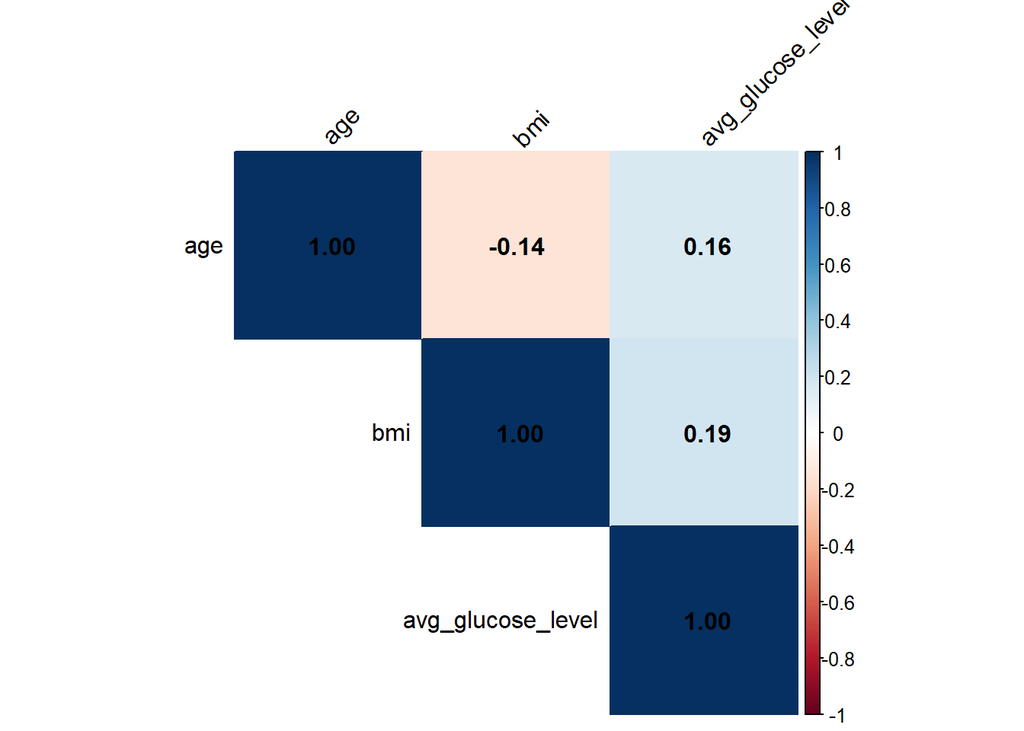

```r
corrplot(
  correlation,
  method = "color",
  type = "upper",
  addCoef.col = "black",     # Adding correlation coefficients
  tl.col = "black",          # Variable label color
  tl.srt = 45               # Rotating labels
)
```

- bmi, glucose level, and age have very weak relationships with each other.
  - Age and bmi have a very weak negative relationship.
  - Age and glucose level and bmi and glucose level have a very weak positive relationship.

```r
#Missingness
missing <- stroke_prediction %>%
  miss_var_summary()
missing
```

```
## # A tibble: 19 × 3
##    variable                   n_miss pct_miss
##    <chr>                       <int>    <num>
##  1 bmi                           145     4.93
##  2 bmi_weight_obesity            145     4.93
##  3 id                              0     0
##  4 gender                          0     0
##  5 age                             0     0
##  6 age_group                       0     0
##  7 hypertension                    0     0
##  8 hypertension_recorded           0     0
##  9 heart_disease                   0     0
## 10 heart_disease_recorded          0     0
## 11 ever_married                    0     0
## 12 work_type                       0     0
## 13 Residence_type                  0     0
## 14 avg_glucose_level               0     0
## 15 avg_glucose_level_diabetes      0     0
## 16 smoking_status                  0     0
## 17 smoking_status_recorded         0     0
## 18 stroke                          0     0
## 19 stroke_recorded                 0     0
```

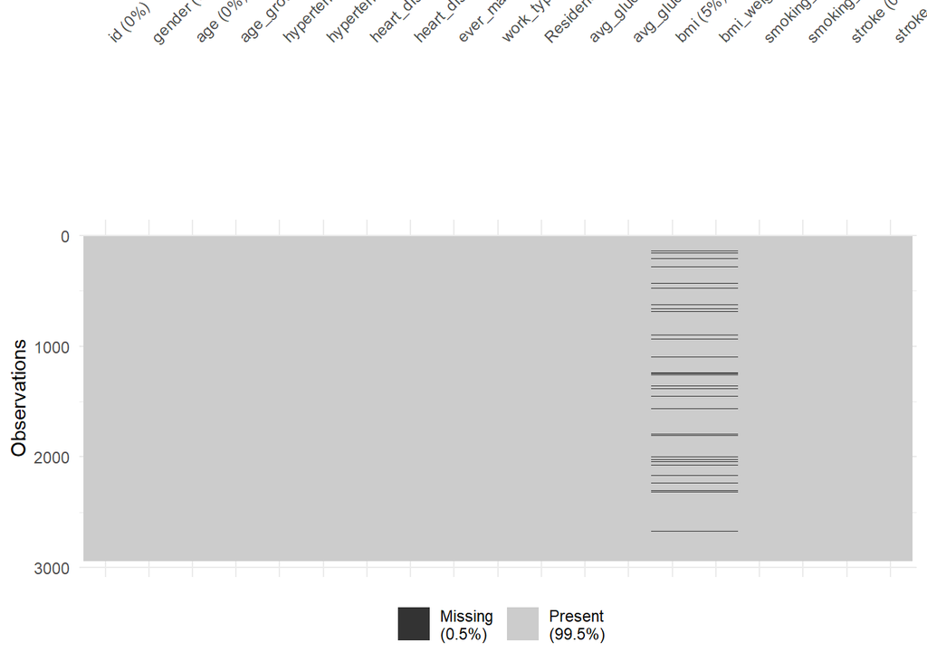

```r
#Visualize
stroke_prediction %>%
  arrange(desc(age)) %>%
  naniar::vis_miss()
```

- bmi has barely 5% missing values.

**Train-Test Split**

```r
#Setting random seed for reproducibility
set.seed(123)

#Splitting the dataset
dataset_split <- initial_split(stroke_prediction, prop = 0.70, strata = stroke_recorded)

training_data <- dataset_split %>%
  training()

testing_data <- dataset_split %>%
  testing()
```

*Determining the proportion of stroke in training, testing sets and the whole dataset*

```r
#WHOLE DATASET
#Proportions/distributions in the overall/main dataset
table(stroke_prediction$stroke_recorded)
```

```
##
## No stroke    Stroke
##      2699       241
```

```r
#TRAINING SET
table(training_data$stroke_recorded)
```

```
##
## No stroke    Stroke
##      1889       169
```

```r
#Percentages for both "No stroke" and "Stroke"
prop.table(table(training_data$stroke_recorded))
```

```
##
##  No stroke     Stroke
## 0.91788144 0.08211856
```

```r
#TESTING SET
table(testing_data$stroke_recorded)
```

```
##
## No stroke    Stroke
##       810        72
```

```r
#Percentages for both "No stroke" and "Stroke"
prop.table(table(testing_data$stroke_recorded))
```

```
##
##  No stroke     Stroke
## 0.91836735 0.08163265
```

**Feature Engineering**

```r
#Selecting the variables I need for modelling.

colnames(stroke_prediction)
```

```
##  [1] "id"                         "gender"
##  [3] "age"                        "age_group"
##  [5] "hypertension"               "hypertension_recorded"
##  [7] "heart_disease"              "heart_disease_recorded"
##  [9] "ever_married"               "work_type"
## [11] "Residence_type"             "avg_glucose_level"
## [13] "avg_glucose_level_diabetes" "bmi"
## [15] "bmi_weight_obesity"         "smoking_status"
## [17] "smoking_status_recorded"    "stroke"
## [19] "stroke_recorded"
```

```r
training_data <- training_data%>%
  select(gender, age_group, hypertension_recorded, heart_disease_recorded, ever_married, work_type, Residence_type, avg_glucose_level_diabetes, bmi, bmi_weight_obesity, smoking_status_recorded, stroke_recorded)

View(training_data)
```

```r
library(themis)

#bmi values are Missing Completely At Random (MCAR), therefore, it is safe to do median imputation


#Creating a recipe and performing upsampling to deal with class imbalance
stroke_recipe <- recipe(stroke_recorded ~ .,
                        data = training_data) %>%
  step_impute_median(bmi)%>% #Median imputation
  step_string2factor(all_categorical()) %>% #Converting categorical vars to factors
  step_mutate(
    bmi_weight_obesity = case_when(
    bmi < 25.0 ~ "Underweight/Normal (<25.0)",
    bmi >= 25.0 & bmi < 30.0 ~ "Overweight (25.0-30.0)",
    bmi >= 30.0 ~ "Obesity (>=30.0)",
    TRUE ~ NA
  )) %>%
  step_mutate(bmi_weight_obesity = factor(bmi_weight_obesity,
                                     levels = c("Obesity (>=30.0)",
                                                "Underweight/Normal (<25.0)",
                                                "Overweight (25.0-30.0)")))%>%
  step_rm(bmi) %>%
  step_upsample(stroke_recorded)

#Upsampling performed better than SMOTE, so I moved forward with upsampling.
```

- I have performed upsampling on the outcome variable to prevent the model from making predictions based on the majority class only.

**LOGISTIC REGRESSION MODEL**

```r
#Defining the model
stroke_model <- logistic_reg() %>%
  set_engine('glm') %>%
  set_mode('classification')

stroke_model
```

```
## Logistic Regression Model Specification (classification)
##
## Computational engine: glm
```

```r
library(workflows)
#Creating a workflow
stroke_workflow <- workflows::workflow()%>%
  add_model(stroke_model)%>%
  add_recipe(stroke_recipe)

stroke_workflow
```

```
## ══ Workflow ════════════════════════════════════════════════════════════════════
## Preprocessor: Recipe
## Model: logistic_reg()
##
## ── Preprocessor ────────────────────────────────────────────────────────────────
## 6 Recipe Steps
##
## • step_impute_median()
## • step_string2factor()
## • step_mutate()
## • step_mutate()
## • step_rm()
## • step_upsample()
##
## ── Model ───────────────────────────────────────────────────────────────────────
## Logistic Regression Model Specification (classification)
##
## Computational engine: glm
```

```r
#Fitting/Training the model
stroke_workflow_fit <- stroke_workflow %>%
  fit(data = training_data)
```

*Testing set Predictions*

```r
#Obtaining model predictions
logistic_class <- predict(stroke_workflow_fit,
                          new_data = testing_data,
                          type = "class")

logistic_prob <- predict(stroke_workflow_fit,
                         new_data = testing_data,
                         type = "prob")

logistic_predictions <- bind_cols(logistic_class,
                                  logistic_prob,
                                  testing_data)%>%
  relocate(stroke_recorded, .before = .pred_class)


View(logistic_predictions)
```

*Confusion matrix*

```r
#Confusion matrix
conf_mat(logistic_predictions, truth = stroke_recorded, estimate = .pred_class)
```

```
##            Truth
## Prediction  No stroke Stroke
##   No stroke       513     19
##   Stroke          297     53
```

```r
conf_mat(logistic_predictions,
         truth = stroke_recorded,
         estimate = .pred_class)%>%
  summary()
```

```
## # A tibble: 13 × 3
##    .metric              .estimator .estimate
##    <chr>                <chr>          <dbl>
##  1 accuracy             binary         0.642
##  2 kap                  binary         0.134
##  3 sens                 binary         0.633
##  4 spec                 binary         0.736
##  5 ppv                  binary         0.964
##  6 npv                  binary         0.151
##  7 mcc                  binary         0.207
##  8 j_index              binary         0.369
##  9 bal_accuracy         binary         0.685
## 10 detection_prevalence binary         0.603
## 11 precision            binary         0.964
## 12 recall               binary         0.633
## 13 f_meas               binary         0.765
```

- Accuracy is not the best metric to consider because our classes are highly imbalanced. In this case **Sensitivity** (capturing true positives), **balanced accuracy** (overall performance accounting for class imbalance), **ROC AUC** (overall model discrimination), **PR AUC {Precision-Recall AUC}** (minority class performance, **F1-score** (trade-off between precision and recall) give better model evaluation)

  *Model performance*

```r
library(yardstick)

logistic_model_metrics <- metric_set(yardstick::sensitivity,
                                      yardstick::bal_accuracy,
                                      yardstick::precision,
                                      yardstick::recall,
                                      yardstick::f_meas,
                                      yardstick::specificity)

logistic_model_metrics(logistic_predictions,
               truth = stroke_recorded,
               estimate = .pred_class,
               event_level = "second") #Stroke is the event of interest
```

```
## # A tibble: 6 × 3
##   .metric      .estimator .estimate
##   <chr>        <chr>          <dbl>
## 1 sensitivity  binary         0.736
## 2 bal_accuracy binary         0.685
## 3 precision    binary         0.151
## 4 recall       binary         0.736
## 5 f_meas       binary         0.251
## 6 specificity  binary         0.633
```

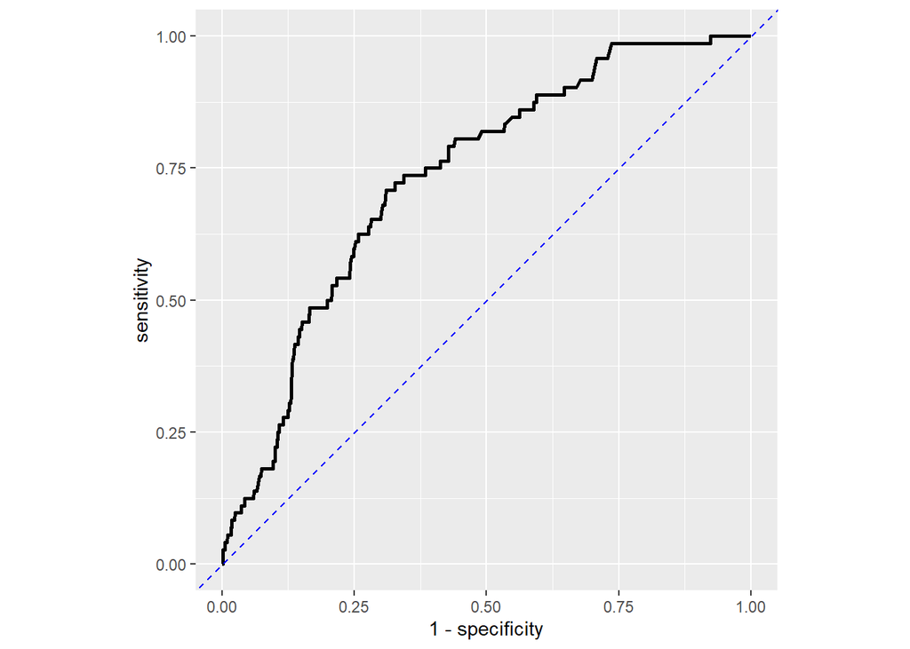

```r
#ROC plot
roc_logit <- logistic_predictions %>%
  roc_curve(truth = stroke_recorded, .pred_Stroke, event_level = "second")

roc_logit %>%
  ggplot(aes(x = 1 - specificity,
             y = sensitivity)) +
  geom_path(linewidth = 1) +
  geom_abline(linetype = 2, colour = "blue") +
  coord_equal()
```

```r
#ROC-AUC value
logistic_predictions %>%
  roc_auc(truth = stroke_recorded, .pred_Stroke, event_level = "second")
```

```
## # A tibble: 1 × 3
##   .metric .estimator .estimate
##   <chr>   <chr>          <dbl>
## 1 roc_auc binary         0.733
```

```r
#PR AUC
logistic_predictions %>%
  pr_auc(truth = stroke_recorded, .pred_Stroke, event_level = "second")
```

```
## # A tibble: 1 × 3
##   .metric .estimator .estimate
##   <chr>   <chr>          <dbl>
## 1 pr_auc  binary         0.176
```

```r
library(broom)
library(dplyr)
library(gt)

results_table <- extract_fit_parsnip(stroke_workflow_fit) %>%
  tidy(exponentiate = TRUE, conf.int = TRUE) %>%
  filter(term != "(Intercept)") %>%
  mutate(`Odds Ratio` = round(estimate, 2),
         `95% CI` = paste0(round(conf.low, 2)," – ", round(conf.high, 2)),
         `P-value` = if_else(p.value < 0.001, "<0.001", sprintf("%.3f", p.value)),
         Significant = if_else(p.value < 0.05, "Yes", "No")) %>%
  arrange(p.value)%>%
  rename(Predictor = term)

results_table %>%
  select(Predictor, `Odds Ratio`, `95% CI`, `P-value`, Significant) %>%
  gt() %>%
  cols_label(Predictor = "Predictor") %>%
  tab_header(title = md("**Multivariable Logistic Regression Model**"),
             subtitle = "Predictors of Stroke") %>%
  fmt_markdown(columns = everything())
```

**Multivariable Logistic Regression Model**

Predictors of Stroke

| Predictor | Odds Ratio | 95% CI | P-value | Significant |
| --- | --- | --- | --- | --- |
| age_groupElderly (>=65) | 51.63 | 26.98 – 115.01 | <0.001 | Yes |
| age_groupMiddle aged (45-64) | 18.26 | 9.56 – 40.61 | <0.001 | Yes |
| hypertension_recordedYes | 1.86 | 1.55 – 2.23 | <0.001 | Yes |
| avg_glucose_level_diabetesDiabetes (>=137mg/dL) | 1.65 | 1.4 – 1.95 | <0.001 | Yes |
| bmi_weight_obesityOverweight (25.0-30.0) | 1.51 | 1.28 – 1.77 | <0.001 | Yes |
| heart_disease_recordedYes | 1.66 | 1.33 – 2.09 | <0.001 | Yes |
| work_typePrivate | 1.28 | 1.04 – 1.58 | 0.018 | Yes |
| ever_marriedYes | 0.77 | 0.6 – 0.99 | 0.040 | Yes |
| smoking_status_recordedSmokers | 1.13 | 0.96 – 1.33 | 0.146 | No |
| avg_glucose_level_diabetesPrediabetes (117-136mg/dL) | 0.8 | 0.55 – 1.16 | 0.241 | No |
| smoking_status_recordedUnknown | 1.12 | 0.91 – 1.38 | 0.266 | No |
| genderMale | 0.93 | 0.8 – 1.08 | 0.358 | No |
| bmi_weight_obesityUnderweight/Normal (<25.0) | 1.04 | 0.84 – 1.29 | 0.697 | No |
| Residence_typeUrban | 1.02 | 0.89 – 1.18 | 0.766 | No |
| work_typeSelf-employed | 1 | 0.79 – 1.26 | 0.987 | No |

**DECISION TREE MODEL**

```r
#Defining the model
dt_stroke_model <- decision_tree() %>%
  set_engine("rpart") %>%
  set_mode("classification")

dt_stroke_model
```

```
## Decision Tree Model Specification (classification)
##
## Computational engine: rpart
```

```r
#Specifying the workflow
dt_stroke_workflow <- workflow() %>%
  add_model(dt_stroke_model) %>%
  add_recipe(stroke_recipe)

dt_stroke_workflow
```

```
## ══ Workflow ════════════════════════════════════════════════════════════════════
## Preprocessor: Recipe
## Model: decision_tree()
##
## ── Preprocessor ────────────────────────────────────────────────────────────────
## 6 Recipe Steps
##
## • step_impute_median()
## • step_string2factor()
## • step_mutate()
## • step_mutate()
## • step_rm()
## • step_upsample()
##
## ── Model ───────────────────────────────────────────────────────────────────────
## Decision Tree Model Specification (classification)
##
## Computational engine: rpart
```

```r
#Fitting the model
dt_stroke_model_fit <- dt_stroke_workflow %>%
  fit(data = training_data)
```

```r
#Model predictions
dt_class <- predict(dt_stroke_model_fit, new_data = testing_data, type = "class")

dt_prob <- predict(dt_stroke_model_fit, new_data = testing_data, type = "prob")

dt_predictions <- bind_cols(dt_class, dt_prob, testing_data) %>%
  relocate(stroke_recorded, .before = .pred_class)

View(dt_predictions)
```

```r
#Confusion matrix
conf_mat(dt_predictions, truth = stroke_recorded, estimate = .pred_class)
```

```
##            Truth
## Prediction  No stroke Stroke
##   No stroke       526     19
##   Stroke          284     53
```

```r
accuracy_metrics <- metric_set(
  yardstick::sensitivity, bal_accuracy, precision, recall,f_meas, yardstick::specificity)

accuracy_metrics(dt_predictions, truth = stroke_recorded, estimate = .pred_class,
               event_level = "second") #Stroke is the event of interest
```

```
## # A tibble: 6 × 3
##   .metric      .estimator .estimate
##   <chr>        <chr>          <dbl>
## 1 sensitivity  binary         0.736
## 2 bal_accuracy binary         0.693
## 3 precision    binary         0.157
## 4 recall       binary         0.736
## 5 f_meas       binary         0.259
## 6 specificity  binary         0.649
```

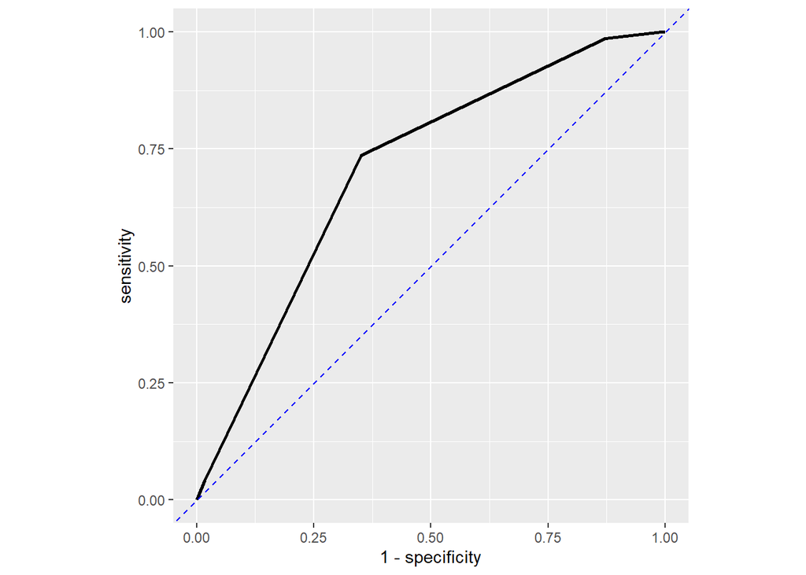

```r
#ROC plot
#ROC plot
roc_dt <- dt_predictions %>%
  roc_curve(truth = stroke_recorded, .pred_Stroke, event_level = "second")

roc_dt %>%
  ggplot(aes(x = 1 - specificity,
             y = sensitivity)) +
  geom_path(linewidth = 1) +
  geom_abline(linetype = 2, colour = "blue") +
  coord_equal()
```

```r
#ROC-AUC value
dt_predictions %>%
  roc_auc(truth = stroke_recorded, .pred_Stroke, event_level = "second")
```

```
## # A tibble: 1 × 3
##   .metric .estimator .estimate
##   <chr>   <chr>          <dbl>
## 1 roc_auc binary         0.706
```

```r
#PR-AUC value
dt_predictions %>%
  pr_auc(truth = stroke_recorded, .pred_Stroke, event_level = "second")
```

```
## # A tibble: 1 × 3
##   .metric .estimator .estimate
##   <chr>   <chr>          <dbl>
## 1 pr_auc  binary         0.173
```

```r
dt_model_tuning <- decision_tree(
  cost_complexity = tune(),
  min_n = tune(),
  tree_depth = tune()) %>%
  set_engine("rpart") %>%
  set_mode("classification")

dt_model_tuning
```

```
## Decision Tree Model Specification (classification)
##
## Main Arguments:
##   cost_complexity = tune()
##   tree_depth = tune()
##   min_n = tune()
##
## Computational engine: rpart
```

```r
#Workflow
dt_tune_workflow <- workflow() %>%
  add_model(dt_model_tuning) %>%
  add_recipe(stroke_recipe)

dt_tune_workflow
```

```
## ══ Workflow ════════════════════════════════════════════════════════════════════
## Preprocessor: Recipe
## Model: decision_tree()
##
## ── Preprocessor ────────────────────────────────────────────────────────────────
## 6 Recipe Steps
##
## • step_impute_median()
## • step_string2factor()
## • step_mutate()
## • step_mutate()
## • step_rm()
## • step_upsample()
##
## ── Model ───────────────────────────────────────────────────────────────────────
## Decision Tree Model Specification (classification)
##
## Main Arguments:
##   cost_complexity = tune()
##   tree_depth = tune()
##   min_n = tune()
##
## Computational engine: rpart
```

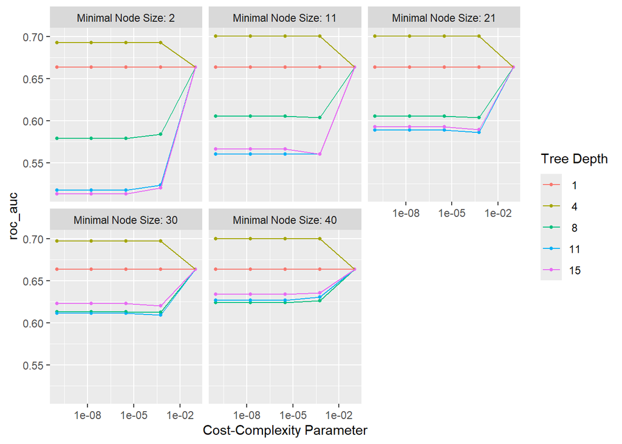

```r
#Creating a regular grid
dt_tune_grid <- grid_regular(extract_parameter_set_dials(dt_model_tuning), levels = 5)


#Cross validation to select the best hyperparameters
set.seed(123)

stroke_cv_folds <- vfold_cv(training_data, v = 10)

dt_tuning_results <- tune_grid(dt_tune_workflow,
                               resamples = stroke_cv_folds,
                               grid = dt_tune_grid,
                               metrics = metric_set(roc_auc))

#Visualization of the tuning results
autoplot(dt_tuning_results)
```

```r
collect_metrics(dt_tuning_results)
```

```
## # A tibble: 125 × 9
##    cost_complexity tree_depth min_n .metric .estimator  mean     n std_err
##              <dbl>      <int> <int> <chr>   <chr>      <dbl> <int>   <dbl>
##  1    0.0000000001          1     2 roc_auc binary     0.664    10  0.0150
##  2    0.0000000001          1    11 roc_auc binary     0.664    10  0.0150
##  3    0.0000000001          1    21 roc_auc binary     0.664    10  0.0150
##  4    0.0000000001          1    30 roc_auc binary     0.664    10  0.0150
##  5    0.0000000001          1    40 roc_auc binary     0.664    10  0.0150
##  6    0.0000000001          4     2 roc_auc binary     0.693    10  0.0157
##  7    0.0000000001          4    11 roc_auc binary     0.701    10  0.0143
##  8    0.0000000001          4    21 roc_auc binary     0.701    10  0.0143
##  9    0.0000000001          4    30 roc_auc binary     0.697    10  0.0139
## 10    0.0000000001          4    40 roc_auc binary     0.700    10  0.0162
## # ℹ 115 more rows
## # ℹ 1 more variable: .config <chr>
```

```r
show_best(dt_tuning_results, metric = "roc_auc")
```

```
## # A tibble: 5 × 9
##   cost_complexity tree_depth min_n .metric .estimator  mean     n std_err
##             <dbl>      <int> <int> <chr>   <chr>      <dbl> <int>   <dbl>
## 1    0.0000000001          4    11 roc_auc binary     0.701    10  0.0143
## 2    0.0000000001          4    21 roc_auc binary     0.701    10  0.0143
## 3    0.0000000178          4    11 roc_auc binary     0.701    10  0.0143
## 4    0.0000000178          4    21 roc_auc binary     0.701    10  0.0143
## 5    0.00000316            4    11 roc_auc binary     0.701    10  0.0143
## # ℹ 1 more variable: .config <chr>
```

```r
#Optimal hyperparameters
best_params <- select_best(dt_tuning_results, metric = "roc_auc")
best_params
```

```
## # A tibble: 1 × 4
##   cost_complexity tree_depth min_n .config
##             <dbl>      <int> <int> <chr>
## 1    0.0000000001          4    11 pre0_mod007_post0
```

```r
#Finalizing the model and fit to make predictions
best_specs <- finalize_model(dt_model_tuning, best_params)
best_specs
```

```
## Decision Tree Model Specification (classification)
##
## Main Arguments:
##   cost_complexity = 1e-10
##   tree_depth = 4
##   min_n = 11
##
## Computational engine: rpart
```

```r
#Generating the final workflow
final_dt_workflow <- dt_tune_workflow %>%
  finalize_workflow(best_params)


#Generating final results using the last_fit() function to train, test, make predictions and test automatically
final_dt_results <- final_dt_workflow %>%
  last_fit(split = dataset_split,
           metrics = metric_set(roc_auc, pr_auc, yardstick::sensitivity, yardstick::specificity, bal_accuracy, f_meas))

dt_tuned_predictions <- collect_predictions(final_dt_results)

collect_metrics(final_dt_results)
```

```
## # A tibble: 6 × 4
##   .metric      .estimator .estimate .config
##   <chr>        <chr>          <dbl> <chr>
## 1 sensitivity  binary         0.604 pre0_mod0_post0
## 2 specificity  binary         0.667 pre0_mod0_post0
## 3 bal_accuracy binary         0.635 pre0_mod0_post0
## 4 f_meas       binary         0.739 pre0_mod0_post0
## 5 roc_auc      binary         0.671 pre0_mod0_post0
## 6 pr_auc       binary         0.942 pre0_mod0_post0
```

**RANDOM FOREST MODEL**

```r
library(ranger)

#Defining the model
rf_stroke_model <- rand_forest() %>%
  set_engine("ranger") %>%
  set_mode("classification")

rf_stroke_model
```

```
## Random Forest Model Specification (classification)
##
## Computational engine: ranger
```

```r
#Defining a workflow
rf_stroke_workflow <- workflow() %>%
  add_model(rf_stroke_model) %>%
  add_recipe(stroke_recipe)

rf_stroke_workflow
```

```
## ══ Workflow ════════════════════════════════════════════════════════════════════
## Preprocessor: Recipe
## Model: rand_forest()
##
## ── Preprocessor ────────────────────────────────────────────────────────────────
## 6 Recipe Steps
##
## • step_impute_median()
## • step_string2factor()
## • step_mutate()
## • step_mutate()
## • step_rm()
## • step_upsample()
##
## ── Model ───────────────────────────────────────────────────────────────────────
## Random Forest Model Specification (classification)
##
## Computational engine: ranger
```

```r
#Model fit
rf_stroke_model_fit <- rf_stroke_workflow %>%
  fit(data = training_data)
```

```r
#Model predictions
rf_class <- predict(rf_stroke_model_fit, new_data = testing_data, type = "class")

rf_prob <- predict(rf_stroke_model_fit, new_data = testing_data, type = "prob")

rf_predictions <- bind_cols(rf_class, rf_prob, testing_data) %>%
  relocate(stroke_recorded, .before = .pred_class)

View(rf_predictions)
```

```r
#Confusion matrix
conf_mat(rf_predictions, truth = stroke_recorded, estimate = .pred_class)
```

```
##            Truth
## Prediction  No stroke Stroke
##   No stroke       648     57
##   Stroke          162     15
```

```r
accuracy_metrics <- metric_set(yardstick::sensitivity, bal_accuracy, precision, recall,f_meas, yardstick::specificity)

accuracy_metrics(rf_predictions, truth = stroke_recorded, estimate = .pred_class,
               event_level = "second") #Stroke is the event of interest
```

```
## # A tibble: 6 × 3
##   .metric      .estimator .estimate
##   <chr>        <chr>          <dbl>
## 1 sensitivity  binary        0.208
## 2 bal_accuracy binary        0.504
## 3 precision    binary        0.0847
## 4 recall       binary        0.208
## 5 f_meas       binary        0.120
## 6 specificity  binary        0.8
```

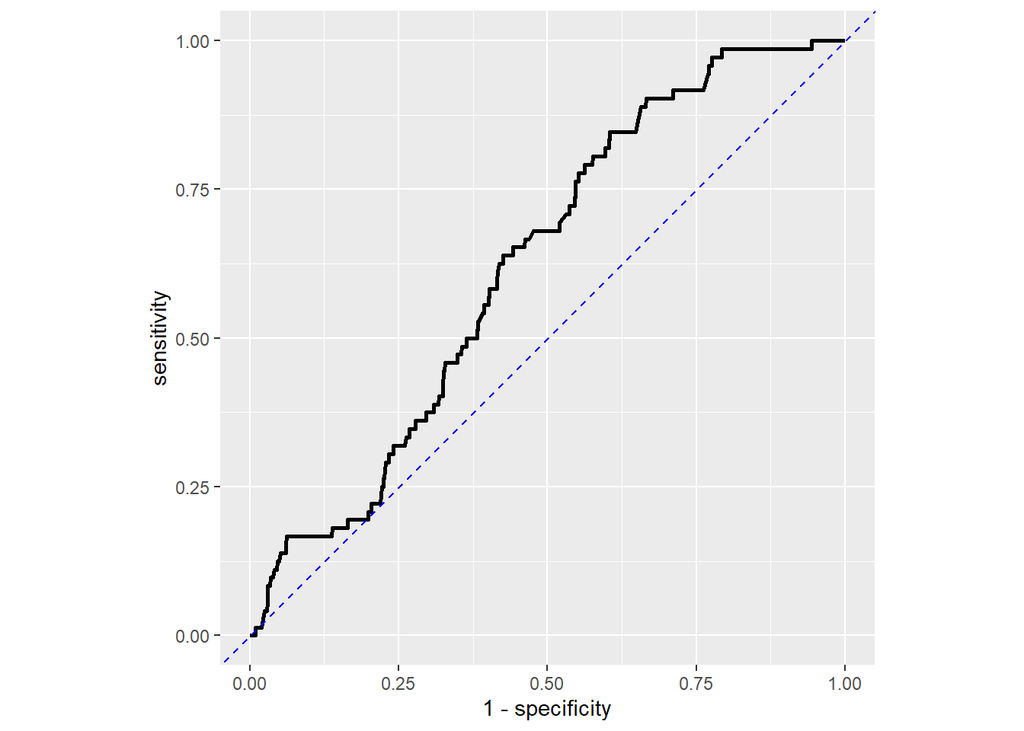

```r
#ROC plot
roc_rf <- rf_predictions %>%
  roc_curve(truth = stroke_recorded, .pred_Stroke, event_level = "second")

roc_rf %>%
  ggplot(aes(x = 1 - specificity,
             y = sensitivity)) +
  geom_path(linewidth = 1) +
  geom_abline(linetype = 2, colour = "blue") +
  coord_equal()
```

```r
#ROC-AUC value
rf_predictions %>%
  roc_auc(truth = stroke_recorded, .pred_Stroke, event_level = "second")
```

```
## # A tibble: 1 × 3
##   .metric .estimator .estimate
##   <chr>   <chr>          <dbl>
## 1 roc_auc binary         0.623
```

```r
#PR-AUC value
rf_predictions %>%
  pr_auc(truth = stroke_recorded, .pred_Stroke, event_level = "second")
```

```
## # A tibble: 1 × 3
##   .metric .estimator .estimate
##   <chr>   <chr>          <dbl>
## 1 pr_auc  binary         0.112
```

```r
rf_model_tuning <- rand_forest(mtry = tune(),
                               min_n = tune(),
                               trees = 500) %>%
  set_engine("ranger") %>%
  set_mode("classification")

rf_model_tuning
```

```
## Random Forest Model Specification (classification)
##
## Main Arguments:
##   mtry = tune()
##   trees = 500
##   min_n = tune()
##
## Computational engine: ranger
```

```r
#Workflow
rf_tune_workflow <- workflow() %>%
  add_model(rf_model_tuning) %>%
  add_recipe(stroke_recipe)

rf_tune_workflow
```

```
## ══ Workflow ════════════════════════════════════════════════════════════════════
## Preprocessor: Recipe
## Model: rand_forest()
##
## ── Preprocessor ────────────────────────────────────────────────────────────────
## 6 Recipe Steps
##
## • step_impute_median()
## • step_string2factor()
## • step_mutate()
## • step_mutate()
## • step_rm()
## • step_upsample()
##
## ── Model ───────────────────────────────────────────────────────────────────────
## Random Forest Model Specification (classification)
##
## Main Arguments:
##   mtry = tune()
##   trees = 500
##   min_n = tune()
##
## Computational engine: ranger
```

```r
#Creating a random grid
rf_params <- extract_parameter_set_dials(rf_tune_workflow) %>%
  finalize(training_data)

rf_tune_grid <- grid_random(rf_params, size = 10) #10 random hyperparameter combinations


#Cross validation to select the best hyperparameters
set.seed(123)

stroke_cv_folds <- vfold_cv(training_data, v = 10)

rf_tuning_results <- tune_grid(rf_tune_workflow,
                               resamples = stroke_cv_folds,
                               grid = rf_tune_grid,
                               metrics = metric_set(roc_auc))


collect_metrics(rf_tuning_results)
```

```
## # A tibble: 10 × 8
##     mtry min_n .metric .estimator  mean     n std_err .config
##    <int> <int> <chr>   <chr>      <dbl> <int>   <dbl> <chr>
##  1     1    12 roc_auc binary     0.699    10  0.0226 pre0_mod01_post0
##  2     4    28 roc_auc binary     0.618    10  0.0203 pre0_mod02_post0
##  3     8     2 roc_auc binary     0.579    10  0.0233 pre0_mod03_post0
##  4     8    16 roc_auc binary     0.589    10  0.0200 pre0_mod04_post0
##  5     8    27 roc_auc binary     0.601    10  0.0196 pre0_mod05_post0
##  6     9    29 roc_auc binary     0.602    10  0.0195 pre0_mod06_post0
##  7    11    17 roc_auc binary     0.592    10  0.0192 pre0_mod07_post0
##  8    11    29 roc_auc binary     0.602    10  0.0190 pre0_mod08_post0
##  9    12    35 roc_auc binary     0.606    10  0.0185 pre0_mod09_post0
## 10    12    39 roc_auc binary     0.611    10  0.0181 pre0_mod10_post0
```

```r
show_best(rf_tuning_results, metric = "roc_auc")
```

```
## # A tibble: 5 × 8
##    mtry min_n .metric .estimator  mean     n std_err .config
##   <int> <int> <chr>   <chr>      <dbl> <int>   <dbl> <chr>
## 1     1    12 roc_auc binary     0.699    10  0.0226 pre0_mod01_post0
## 2     4    28 roc_auc binary     0.618    10  0.0203 pre0_mod02_post0
## 3    12    39 roc_auc binary     0.611    10  0.0181 pre0_mod10_post0
## 4    12    35 roc_auc binary     0.606    10  0.0185 pre0_mod09_post0
## 5    11    29 roc_auc binary     0.602    10  0.0190 pre0_mod08_post0
```

```r
#Optimal hyperparameters
best_params <- select_best(rf_tuning_results, metric = "roc_auc")
best_params
```

```
## # A tibble: 1 × 3
##    mtry min_n .config
##   <int> <int> <chr>
## 1     1    12 pre0_mod01_post0
```

```r
#Finalizing the model and fit to make predictions
best_specs <- finalize_model(rf_model_tuning, best_params)
best_specs
```

```
## Random Forest Model Specification (classification)
##
## Main Arguments:
##   mtry = 1
##   trees = 500
##   min_n = 12
##
## Computational engine: ranger
```

```r
#Generating the final workflow
final_rf_workflow <- rf_tune_workflow %>%
  finalize_workflow(best_params)


#Generating final results using the last_fit() function to train, test, make predictions and test automatically
final_rf_results <- final_rf_workflow %>%
  last_fit(split = dataset_split,
           metrics = metric_set(roc_auc, pr_auc, yardstick::sensitivity, yardstick::specificity, bal_accuracy, f_meas))

rf_tuned_predictions <- collect_predictions(final_rf_results)

collect_metrics(final_rf_results)
```

```
## # A tibble: 6 × 4
##   .metric      .estimator .estimate .config
##   <chr>        <chr>          <dbl> <chr>
## 1 sensitivity  binary         0.678 pre0_mod0_post0
## 2 specificity  binary         0.653 pre0_mod0_post0
## 3 bal_accuracy binary         0.665 pre0_mod0_post0
## 4 f_meas       binary         0.793 pre0_mod0_post0
## 5 roc_auc      binary         0.711 pre0_mod0_post0
## 6 pr_auc       binary         0.964 pre0_mod0_post0
```

**XGBOOST MODEL**

```r
#Defining the model
xgboost_model <- boost_tree() %>%
  set_engine("xgboost") %>%
  set_mode("classification")

xgboost_model
```

```
## Boosted Tree Model Specification (classification)
##
## Computational engine: xgboost
```

```r
#Defining the recipe
xgboost_recipe <- stroke_recipe %>%
  step_dummy(all_nominal(), -all_outcomes()) %>%
  step_zv(all_predictors())



#Defining the workflow
xgboost_workflow <- workflow() %>%
  add_model(xgboost_model) %>%
  add_recipe(xgboost_recipe)

xgboost_workflow
```

```
## ══ Workflow ════════════════════════════════════════════════════════════════════
## Preprocessor: Recipe
## Model: boost_tree()
##
## ── Preprocessor ────────────────────────────────────────────────────────────────
## 8 Recipe Steps
##
## • step_impute_median()
## • step_string2factor()
## • step_mutate()
## • step_mutate()
## • step_rm()
## • step_upsample()
## • step_dummy()
## • step_zv()
##
## ── Model ───────────────────────────────────────────────────────────────────────
## Boosted Tree Model Specification (classification)
##
## Computational engine: xgboost
```

```r
#Fitting the model
xgboost_workflow_fit <- xgboost_workflow %>%
  fit(data = training_data)
```

```r
#Model predictions
xgb_class <- predict(xgboost_workflow_fit, new_data = testing_data, type = "class")

xgb_prob <- predict(xgboost_workflow_fit, new_data = testing_data, type = "prob")

xgboost_predictions <- bind_cols(xgb_class, xgb_prob, testing_data) %>%
  relocate(stroke_recorded, .before = .pred_class)

View(xgboost_predictions)
```

```r
#Confusion matrix
conf_mat(xgboost_predictions, truth = stroke_recorded, estimate = .pred_class)
```

```
##            Truth
## Prediction  No stroke Stroke
##   No stroke       615     44
##   Stroke          195     28
```

```r
accuracy_metrics <- metric_set(yardstick::sensitivity, bal_accuracy, precision, recall,f_meas, yardstick::specificity)

accuracy_metrics(xgboost_predictions, truth = stroke_recorded, estimate = .pred_class,
               event_level = "second") #Stroke is the event of interest
```

```
## # A tibble: 6 × 3
##   .metric      .estimator .estimate
##   <chr>        <chr>          <dbl>
## 1 sensitivity  binary         0.389
## 2 bal_accuracy binary         0.574
## 3 precision    binary         0.126
## 4 recall       binary         0.389
## 5 f_meas       binary         0.190
## 6 specificity  binary         0.759
```

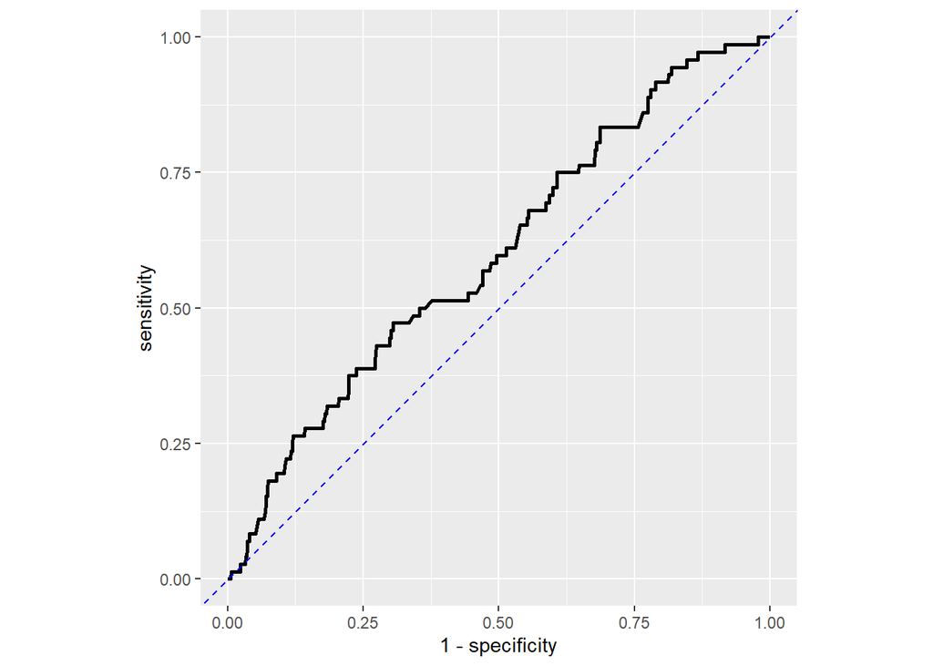

```r
#ROC plot
roc_xgb <- xgboost_predictions %>%
  roc_curve(truth = stroke_recorded, .pred_Stroke, event_level = "second")

roc_xgb %>%
  ggplot(aes(x = 1 - specificity,
             y = sensitivity)) +
  geom_path(linewidth = 1) +
  geom_abline(linetype = 2, colour = "blue") +
  coord_equal()
```

```r
#ROC-AUC value
xgboost_predictions %>%
  roc_auc(truth = stroke_recorded, .pred_Stroke, event_level = "second")
```

```
## # A tibble: 1 × 3
##   .metric .estimator .estimate
##   <chr>   <chr>          <dbl>
## 1 roc_auc binary         0.599
```

```r
#PR-AUC value
xgboost_predictions %>%
  pr_auc(truth = stroke_recorded, .pred_Stroke, event_level = "second")
```

```
## # A tibble: 1 × 3
##   .metric .estimator .estimate
##   <chr>   <chr>          <dbl>
## 1 pr_auc  binary         0.112
```

```r
xgb_model_tuning <- boost_tree(mtry = tune(),
                               min_n = tune(),
                               trees = tune(),
                               tree_depth = tune(),
                               learn_rate = tune()) %>%
  set_engine("xgboost") %>%
  set_mode("classification")

xgb_model_tuning
```

```
## Boosted Tree Model Specification (classification)
##
## Main Arguments:
##   mtry = tune()
##   trees = tune()
##   min_n = tune()
##   tree_depth = tune()
##   learn_rate = tune()
##
## Computational engine: xgboost
```

```r
#Workflow
xgb_tune_workflow <- workflow() %>%
  add_model(xgb_model_tuning) %>%
  add_recipe(xgboost_recipe)

xgb_tune_workflow
```

```
## ══ Workflow ════════════════════════════════════════════════════════════════════
## Preprocessor: Recipe
## Model: boost_tree()
##
## ── Preprocessor ────────────────────────────────────────────────────────────────
## 8 Recipe Steps
##
## • step_impute_median()
## • step_string2factor()
## • step_mutate()
## • step_mutate()
## • step_rm()
## • step_upsample()
## • step_dummy()
## • step_zv()
##
## ── Model ───────────────────────────────────────────────────────────────────────
## Boosted Tree Model Specification (classification)
##
## Main Arguments:
##   mtry = tune()
##   trees = tune()
##   min_n = tune()
##   tree_depth = tune()
##   learn_rate = tune()
##
## Computational engine: xgboost
```

```r
#Creating a random grid
xgb_params <- extract_parameter_set_dials(xgb_tune_workflow) %>%
  finalize(training_data)

xgb_tune_grid <- grid_random(xgb_params, size = 10) #10 random hyperparameter combinations


#Cross validation to select the best hyperparameters
set.seed(123)

stroke_cv_folds <- vfold_cv(training_data, v = 10)

xgb_tuning_results <- tune_grid(xgb_tune_workflow,
                               resamples = stroke_cv_folds,
                               grid = xgb_tune_grid,
                               metrics = metric_set(roc_auc))


collect_metrics(xgb_tuning_results)
```

```
## # A tibble: 10 × 11
##     mtry trees min_n tree_depth learn_rate .metric .estimator  mean     n
##    <int> <int> <int>      <int>      <dbl> <chr>   <chr>      <dbl> <int>
##  1     1   398    13          4    0.247   roc_auc binary     0.627    10
##  2     2  1357    32          4    0.00175 roc_auc binary     0.722    10
##  3     4   740    26         13    0.0785  roc_auc binary     0.616    10
##  4     6  1289    35         10    0.00107 roc_auc binary     0.716    10
##  5     6  1750    35          4    0.00251 roc_auc binary     0.709    10
##  6     6  1784    19         15    0.0486  roc_auc binary     0.579    10
##  7     7  1954     3          5    0.102   roc_auc binary     0.537    10
##  8     8   217    10          6    0.00330 roc_auc binary     0.698    10
##  9     9   999    10          4    0.0177  roc_auc binary     0.638    10
## 10     9  1641    38          8    0.00189 roc_auc binary     0.703    10
## # ℹ 2 more variables: std_err <dbl>, .config <chr>
```